# Plastic Pirates EU Analsysis

Dr. Antonio Canepa-Oneto & Dr. Patricia De La Fuente-Gamero

2026-04-14

# Data Analysis

## Loading Packages

Loading R packages necessary to perform the **EDA**.

## RESEARCH QUESTIONS

### Citizens Description

#### Numer of samplings per year and country

- Table

| CountryResponsible | SamplingYear | Num_Sampling |
| --- | --- | --- |
| austria | 2021 | 1 |
| austria | 2022 | 17 |
| austria | 2023 | 58 |
| austria | 2024 | 66 |
| belgium | 2022 | 22 |
| belgium | 2024 | 31 |
| bulgaria | 2023 | 10 |
| germany | 2022 | 75 |
| germany | 2023 | 11 |
| germany | 2024 | 6 |

[output cut: 19 more lines]

- Plot

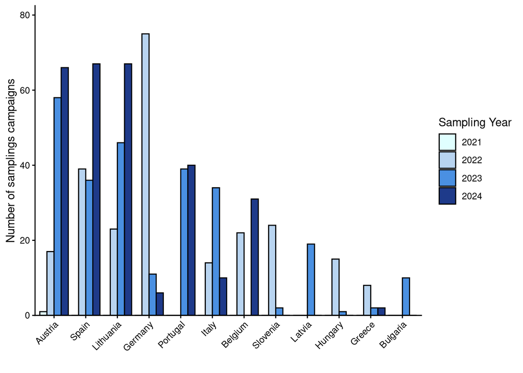

#### Numer of Rivers sampled per year and country

- Table

| CountryResponsible | SamplingYear | Rivers |
| --- | --- | --- |
| austria | 2021 | 1 |
| austria | 2022 | 10 |
| austria | 2023 | 35 |
| austria | 2024 | 35 |
| belgium | 2022 | 12 |
| belgium | 2024 | 18 |
| bulgaria | 2023 | 1 |
| germany | 2022 | 58 |
| germany | 2023 | 10 |
| germany | 2024 | 5 |

[output cut: 19 more lines]

- Plot (without numbers)

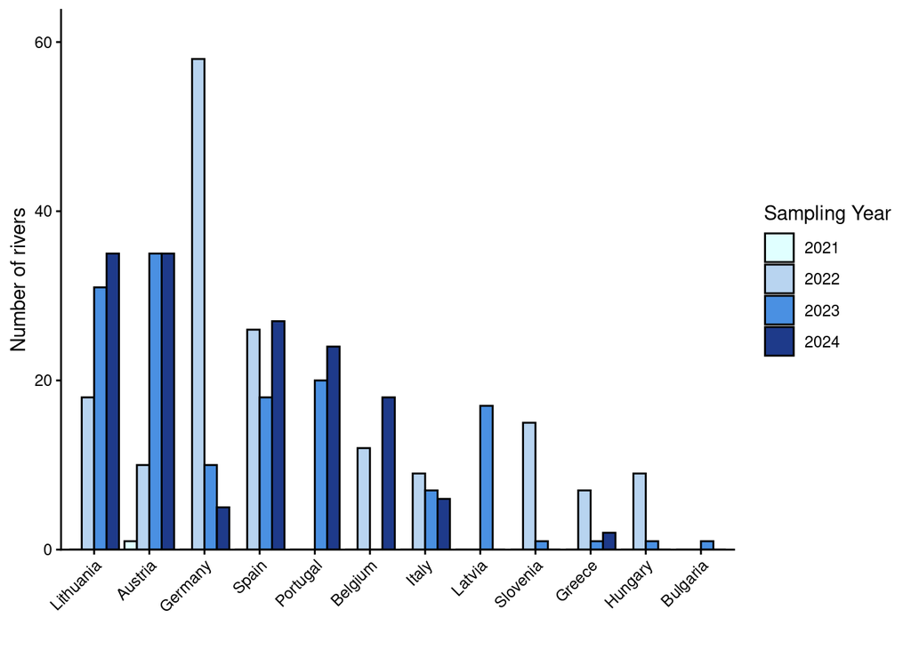

- Plot (with numbers)

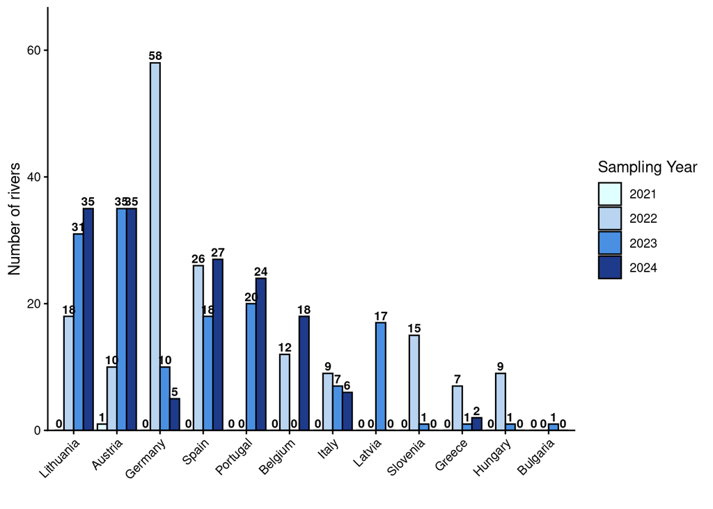

### Most common types and quantities of litter per region? (Group B: riverbanks; Group C: floating litter)

#### Group B: Riverside Waste

Statistics of the variable `RiversideWasteVariety_AttemptedSampling` to see how many samplings were performed.

```
## RiversideWasteVariety_AttemptedSampling
##   0   1
##  27 756
```

To work with the `RiversideWasteVariety_` data, we need to filter the dataset to include only those rows where `RiversideWasteVariety_AttemptedSampling` is 1 (indicating that a sampling was attempted) and `RiversideWasteVariety_Qualified` is also 1 (indicating that the sampling was qualified).

##### Percentage of qualified samplings

This represents the percentage of validated data among the total number of sampling beign attempted.

| total_rows | total_valid | pct_valid_total | pct_valid_percent |
| --- | --- | --- | --- |
| 785 | 551 | 70.2 | 70.2% |

| CountryResponsible | total_rows | total_valid | pct_valid_total(%) | total_attempts | valid_among_attempts | pct_valid_among_attempts(%) |
| --- | --- | --- | --- | --- | --- | --- |
| Austria | 142 | 74 | 52.1 | 128 | 74 | 57.8 |
| Belgium | 53 | 49 | 92.5 | 52 | 49 | 94.2 |
| Bulgaria | 10 | 10 | 100.0 | 10 | 10 | 100.0 |
| Germany | 92 | 86 | 93.5 | 91 | 86 | 94.5 |
| Greece | 12 | 11 | 91.7 | 11 | 11 | 100.0 |
| Hungary | 16 | 15 | 93.8 | 16 | 15 | 93.8 |
| Italy | 58 | 51 | 87.9 | 55 | 51 | 92.7 |
| Latvia | 19 | 10 | 52.6 | 19 | 10 | 52.6 |
| Lithuania | 136 | 90 | 66.2 | 133 | 90 | 67.7 |
| Portugal | 79 | 45 | 57.0 | 77 | 45 | 58.4 |

[output cut: 2 more lines]

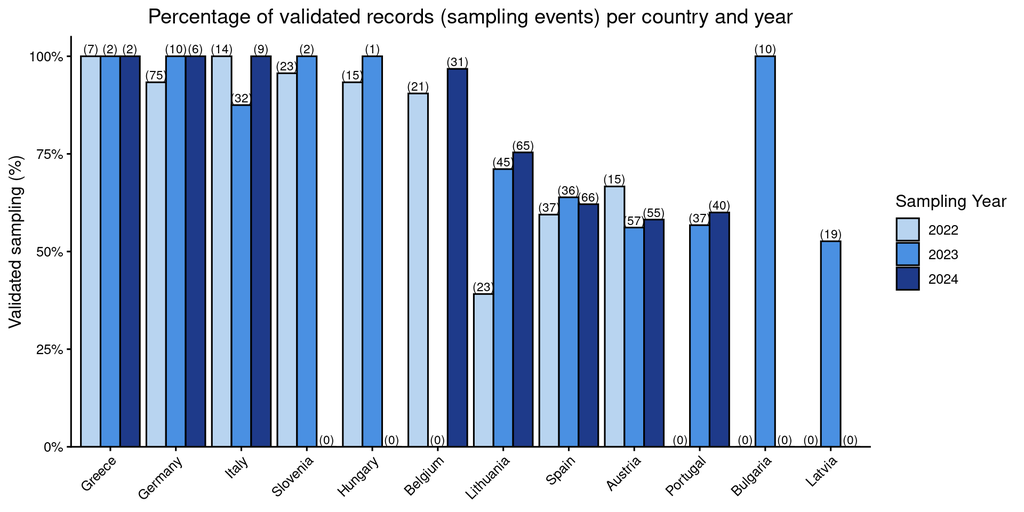

##### Most common types/quantities of litter

Firstly, we will pick up data to answer the question about group B. Only some variables are taken from the general dataset.

The, Attributes’ names are so complicated to work that I’ll remote the preceding information **RiversideWasteVariety_Results_** which is common to all attributes; and finally to work with only the validated `Group B` dataset we create:

**CAUTION**! There are some `NAs` values in the litter items that are probably incorrect since the groups did find other items.

After meeting and email from Charlotte, we realise that NA in group B for some items it’s really a zero. So we update these columns replacing `NA` values with a `0`.

###### Litter type abundance

We will obtain the plot for the most common (average abundance) litter type, as a table and then as a plot.

|  | Litter_type | Av_Abundance | SE_Abundance |
| --- | --- | --- | --- |
| 1 | CigaretteButts | 23.52 | 2.54 |
| 2 | GlassPieces | 17.29 | 3.94 |
| 3 | OtherUnidentifiablePlastic | 12.07 | 1.37 |
| 4 | WetWipesSanitaryProducts | 11.97 | 4.47 |
| 5 | Paper | 10.7 | 0.74 |
| 6 | PlasticPackagingSweets | 9.98 | 0.66 |
| 7 | SmallPlasticPieces.2.5cm | 9.3 | 1.94 |
| 8 | PlasticBags | 7.51 | 0.69 |
| 9 | Polystyrene | 6.56 | 1.35 |
| 10 | PlasticBottles | 6.33 | 1.29 |

[output cut: 15 more lines]

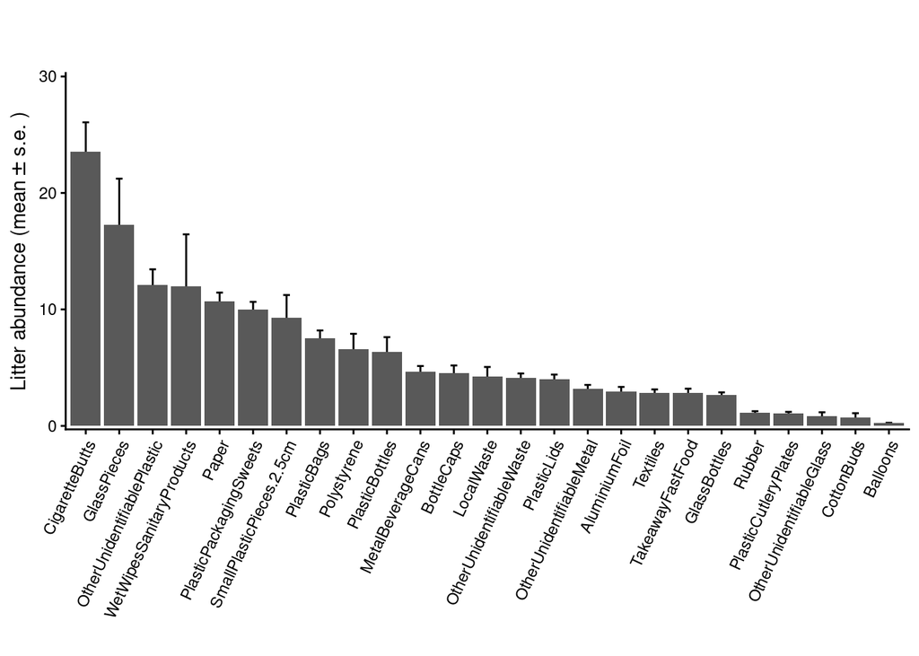

###### Litter type abundance per country

If we now want to visualize the contribution per each country, we have:

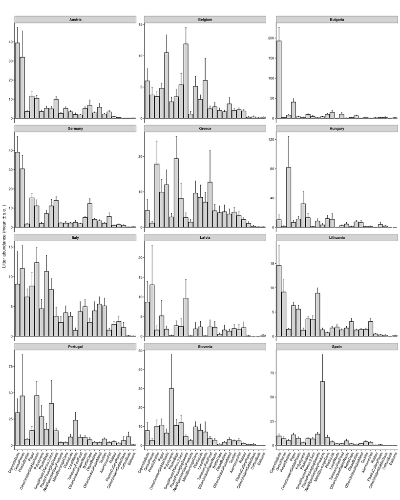

###### Litter type Proportion I - “Across‑type” proportions

- The first approach will be a “*Across‑type*” proportions.
  - For each litter type, what fraction comes from each country? (not from an european total)
  - total abundance of that litter type over each total country.

| CountryResponsible | Litter_type | Total_Abundance | Global_Total | Prop_Country |
| --- | --- | --- | --- | --- |
| austria | AluminiumFoil | 246 | 1636 | 0.1503667482 |
| austria | Balloons | 12 | 126 | 0.0952380952 |
| austria | BottleCaps | 503 | 2501 | 0.2011195522 |
| austria | CigaretteButts | 2915 | 12962 | 0.2248881345 |
| austria | CottonBuds | 6 | 396 | 0.0151515152 |
| austria | GlassBottles | 209 | 1462 | 0.1429548564 |
| austria | GlassPieces | 2364 | 9527 | 0.2481368741 |
| austria | LocalWaste | 146 | 2343 | 0.0623132736 |
| austria | MetalBeverageCans | 383 | 2551 | 0.1501372011 |
| austria | OtherUnidentifiableGlass | 3 | 462 | 0.0064935065 |

[output cut: 290 more lines]

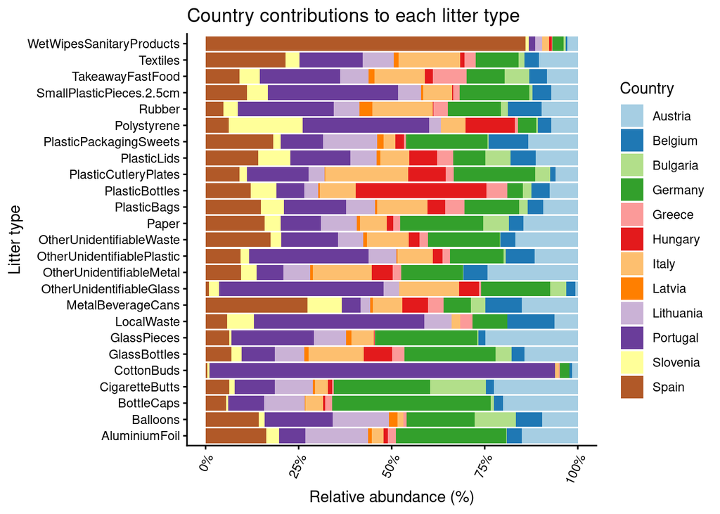

- HeatMaps

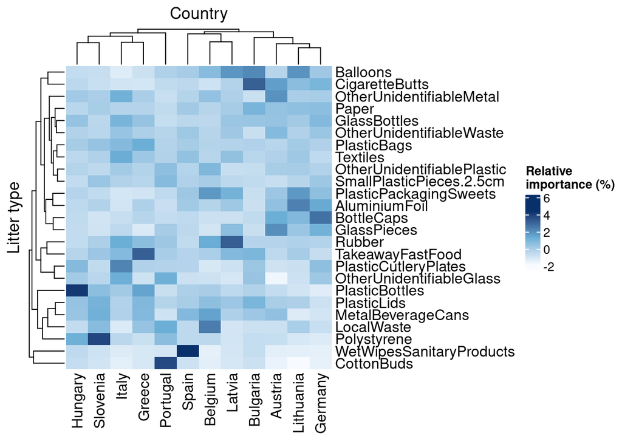

###### Multivariate Perspective

In order to see if there are significant differences across country in the community composition, we will perform a PERMANOVA test:

```
## Permutation test for adonis under reduced model
## Marginal effects of terms
## Permutation: free
## Number of permutations: 999
##
## adonis2(formula = dist_mat ~ CountryResponsible, data = meta, permutations = 999, by = "margin")
##                     Df SumOfSqs      R2      F Pr(>F)
## CountryResponsible  11   27.724 0.09814 5.3324  0.001 ***
## Residual           539  254.764 0.90186
## Total              550  282.488 1.00000
## ---
## Signif. codes:  0 '***' 0.001 '**' 0.01 '*' 0.05 '.' 0.1 ' ' 1
```

So, we conclude that there are significant differences among countries. but What are the items that explains these differences?

The answer will be addressed by performing a **Multivariate Random Forest**.

```
##
## Call:
##  randomForest(x = comm_hel, y = as.factor(meta$CountryResponsible),      ntree = 500, importance = TRUE)
##                Type of random forest: classification
##                      Number of trees: 500
## No. of variables tried at each split: 5
##
##         OOB estimate of  error rate: 62.43%
## Confusion matrix:
##           austria belgium bulgaria germany greece hungary italy latvia
## austria        31       2        0      12      0       0     6      0
## belgium         6       5        0       2      0       0     5      2
## bulgaria        0       0        9       0      0       1     0      0
## germany        10       3        0      41      0       0     2      0
## greece          1       0        0       0      0       0     6      0
## hungary         2       1        0       1      0       2     3      0
## italy          10       3        0       4      0       0    20      0
## latvia          2       2        0       1      0       0     0      0
## lithuania       9       6        0      19      0       0     1      0
## portugal        5       4        0       7      0       0     7      0
## slovenia        4       0        0       0      0       0     5      0
## spain          16       5        0       7      0       0     6      0
##           lithuania portugal slovenia spain class.error
## austria           6        0        0    17   0.5810811
## belgium          12        3        2    12   0.8979592
## bulgaria          0        0        0     0   0.1000000
## germany          18        6        0     6   0.5232558
## greece            0        2        0     2   1.0000000
## hungary           0        0        0     6   0.8666667
## italy             1        1        0    12   0.6078431
## latvia            5        0        0     0   1.0000000
## lithuania        45        0        0    10   0.5000000
## portugal          3       12        1     6   0.7333333
## slovenia          1        4        0    10   1.0000000
## spain             9        1        0    42   0.5116279
```

Decisions have to be taken carefully since the prediction accuracy is very low (0.38). Furthermore, the estimated error rate (OOB) is high, so conclusion have to be taken with care.

Eventhough, the more important (differential across countries) litter components are:

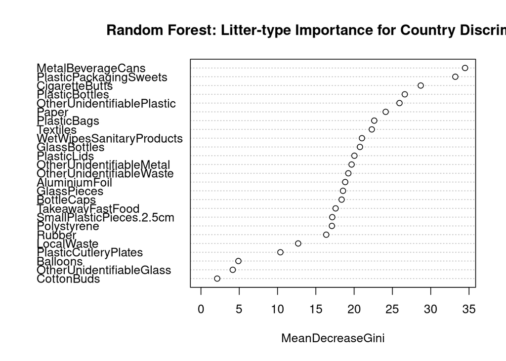

This plot of variable importance importance is telling us:

- A large `MeanDecreaseGini` (**MDG**) means that X frequently appears in high‑up the tree splits and yields big purity gains → it’s structurally important to partitioning the data.
  - **MDG** tells you which features the trees “prefer” splitting on.
- **Principal Component Analysis**

We will perform a Principal Component Analysis (PCA) to see correlation among litter items and *possible* associations with countries

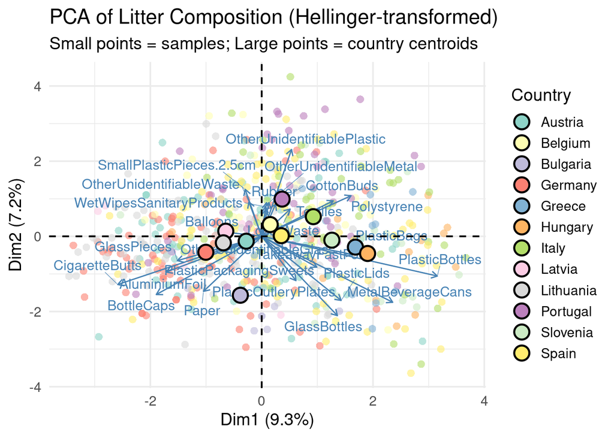

And the most important Items for the two forst principal components are:

- First PC

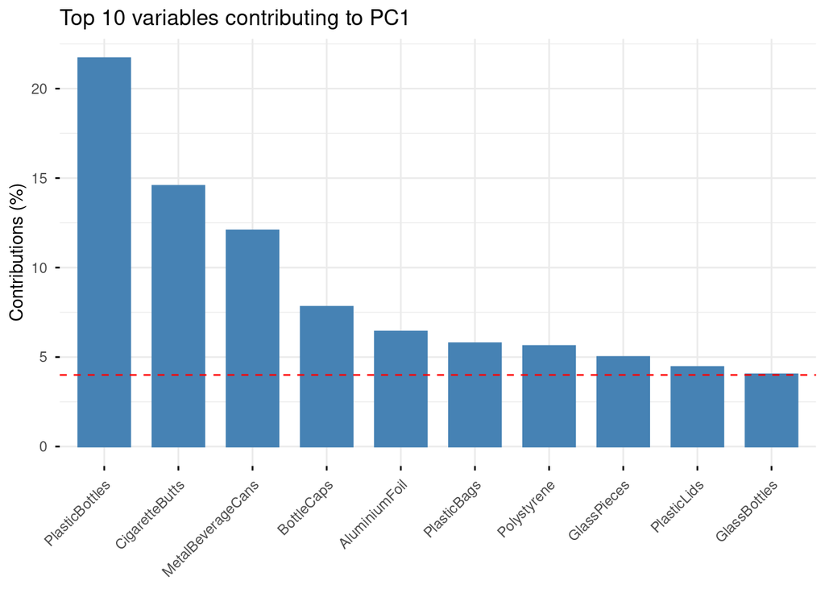

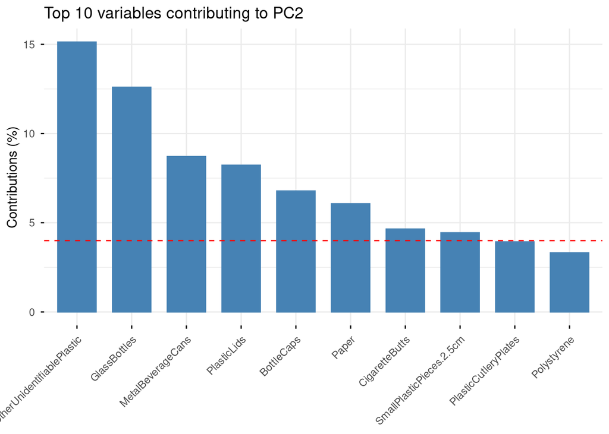

- **Non-Metric Multidimensional Scaling - nMDS**

We will perform a Non-Metric Multidimensional Scaling (nMDS) to see correlation among litter items and *possible* associations with countries.

We can re-use the distance matrix using the hellinger‐transformed data (`comm_hel`) and then perform the nMDS.

```
## [1] 7
```

```
## [1]  84  88 202 205 309 324 400
```

```
## *** Best solution was not repeated -- monoMDS stopping criteria:
##     17: no. of iterations >= maxit
##      3: stress ratio > sratmax
```

Now, we calculate the scores for the sites (samples) and add the metadata to be able to visualize the nMDS with the country information.

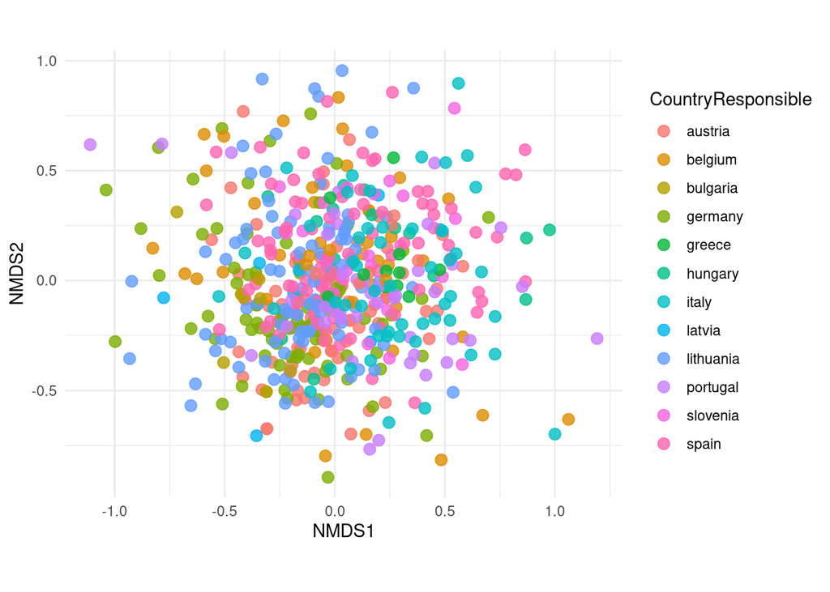

To see which countries are more similar than others, we can calculate the centroids of each country in the NMDS space and then plot them.

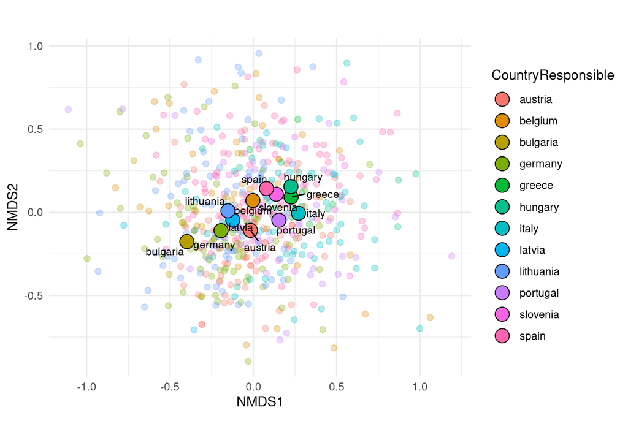

#### Group B: Single Use Plastic - Riverside Waste

We wil take as a subset the single use plastic (`SUP`) for the group B.

|  | DatasetID | CountryResponsible | SamplingCampaign | SamplingYear | SamplingCoordinatesLatitude | SamplingCoordinatesLongitude | SamplingRiverSystem | SamplingParticipants | RiversideWasteVariety_AttemptedSampling | RiversideWasteVariety_Qualified | PlasticBags | PlasticBottles | PlasticLids | TakeawayFastFood | PlasticCutleryPlates | PlasticPackagingSweets | CottonBuds | WetWipesSanitaryProducts | Polystyrene |
| --- | --- | --- | --- | --- | --- | --- | --- | --- | --- | --- | --- | --- | --- | --- | --- | --- | --- | --- | --- |
| 1 | at_6270 | austria | autumn 2022 | 2022 | 48.04275 | 14.42192 | Danube | 9 | 1 | 1 | 2 | 0 | 0 | 2 | 0 | 1 | 0 | 1 | 0 |
| 2 | at_6297 | austria | autumn 2022 | 2022 | 48.26034 | 13.03440 | Danube | 8 | 1 | 1 | 0 | 1 | 4 | 1 | 1 | 14 | 0 | 3 | 0 |
| 3 | at_6382 | austria | autumn 2022 | 2022 | 47.11828 | 13.81419 | Danube | 20 | 1 | 1 | 0 | 0 | 0 | 0 | 0 | 2 | 0 | 0 | 1 |
| 4 | at_6393 | austria | autumn 2022 | 2022 | 46.58301 | 13.84115 | Danube | 38 | 1 | 1 | 34 | 22 | 13 | 2 | 0 | 34 | 0 | 0 | 0 |
| 5 | at_6429 | austria | autumn 2022 | 2022 | 48.21108 | 16.43973 | Danube | 20 | 1 | 1 | 7 | 22 | 17 | 9 | 3 | 10 | 2 | 7 | 6 |
| 6 | at_6429 | austria | autumn 2022 | 2022 | 48.21108 | 16.43973 | Danube | 20 | 1 | 1 | 7 | 22 | 17 | 9 | 3 | 10 | 2 | 7 | 6 |

```
##    DatasetID   CountryResponsible    SamplingCampaign  SamplingYear
##  at_6429:  2   lithuania: 90      autumn 2021:  0     Min.   :2022
##  at_6463:  2   germany  : 86      autumn 2022:198     1st Qu.:2022
##  at_6972:  2   spain    : 86      autumn 2023:144     Median :2023
##  at_6977:  2   austria  : 74      autumn 2024: 50     Mean   :2023
##  de_6237:  2   italy    : 51      spring 2022:  1     3rd Qu.:2024
##  de_6457:  2   belgium  : 49      spring 2023: 26     Max.   :2024
##  (Other):539   (Other)  :115      spring 2024:132
##  SamplingCoordinatesLatitude SamplingCoordinatesLongitude SamplingRiverSystem
##  Min.   :37.18               Min.   :-9.309               Length:551
##  1st Qu.:42.03               1st Qu.: 2.946               Class :character
##  Median :48.07               Median :12.331               Mode  :character
##  Mean   :47.47               Mean   :10.912
##  3rd Qu.:51.33               3rd Qu.:16.923
##  Max.   :57.75               Max.   :27.488
##
##  SamplingParticipants RiversideWasteVariety_AttemptedSampling
##  Min.   :  2.00       Min.   :1
##  1st Qu.: 13.00       1st Qu.:1
##  Median : 19.00       Median :1
##  Mean   : 19.58       Mean   :1
##  3rd Qu.: 24.00       3rd Qu.:1
##  Max.   :250.00       Max.   :1
##  NA's   :10
##  RiversideWasteVariety_Qualified  PlasticBags      PlasticBottles
##  Min.   :1                       Min.   :  0.000   Min.   :  0.000
##  1st Qu.:1                       1st Qu.:  0.000   1st Qu.:  0.000
##  Median :1                       Median :  3.000   Median :  1.000
##  Mean   :1                       Mean   :  7.506   Mean   :  6.334
##  3rd Qu.:1                       3rd Qu.:  7.000   3rd Qu.:  4.000
##  Max.   :1                       Max.   :196.000   Max.   :576.000
##
##   PlasticLids      TakeawayFastFood  PlasticCutleryPlates
##  Min.   :  0.000   Min.   :  0.000   Min.   : 0.000
##  1st Qu.:  0.000   1st Qu.:  0.000   1st Qu.: 0.000
##  Median :  1.000   Median :  0.000   Median : 0.000
##  Mean   :  3.991   Mean   :  2.828   Mean   : 1.044
##  3rd Qu.:  4.000   3rd Qu.:  2.500   3rd Qu.: 1.000
##  Max.   :115.000   Max.   :102.000   Max.   :49.000
##
##  PlasticPackagingSweets   CottonBuds       WetWipesSanitaryProducts
##  Min.   :  0.000        Min.   :  0.0000   Min.   :   0.00
##  1st Qu.:  1.000        1st Qu.:  0.0000   1st Qu.:   0.00
##  Median :  4.000        Median :  0.0000   Median :   0.00
##  Mean   :  9.984        Mean   :  0.7187   Mean   :  11.97
##  3rd Qu.: 11.500        3rd Qu.:  0.0000   3rd Qu.:   2.00
##  Max.   :121.000        Max.   :145.0000   Max.   :1897.00
##
##   Polystyrene
##  Min.   :  0.000
##  1st Qu.:  0.000
##  Median :  0.000
##  Mean   :  6.563
##  3rd Qu.:  2.000
##  Max.   :423.000
##
```

###### SUP type abundance

We will obtain the plot for the most common (average abundance) Single Use Plastic type

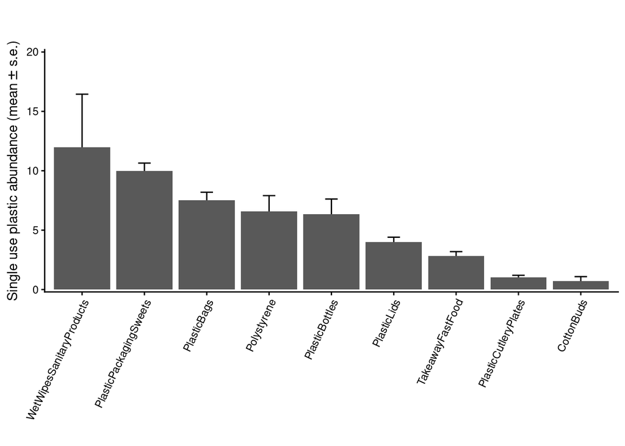

###### SUP type abundance per country

If we now want to visualize the contribution per each country, we have:

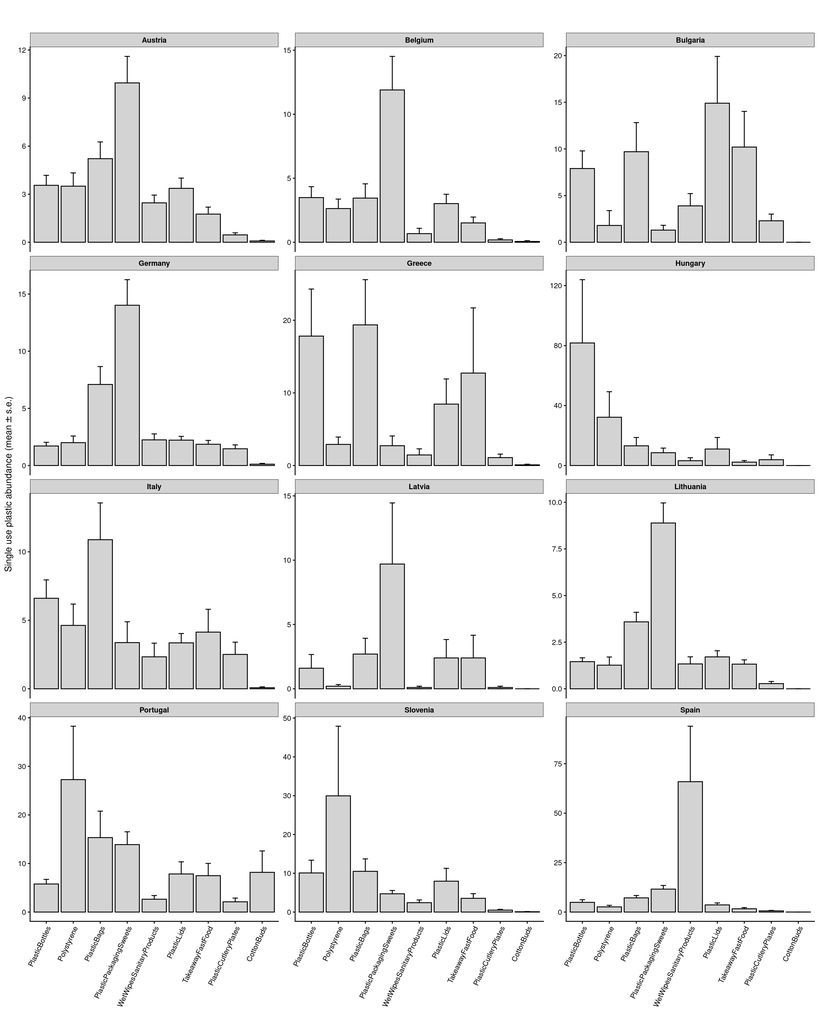

###### SUP type Proportion I - “Across‑type” proportions

- The first approach will be a “*Across‑type*” proportions.
  - total abundance of that litter type over each total country.

| CountryResponsible | Litter_type | Total_Abundance | Global_Total | Prop_Country |
| --- | --- | --- | --- | --- |
| austria | CottonBuds | 6 | 396 | 0.0151515152 |
| austria | PlasticBags | 386 | 4136 | 0.0933268859 |
| austria | PlasticBottles | 263 | 3490 | 0.0753581662 |
| austria | PlasticCutleryPlates | 34 | 575 | 0.0591304348 |
| austria | PlasticLids | 249 | 2199 | 0.1132332879 |
| austria | PlasticPackagingSweets | 736 | 5501 | 0.1337938557 |
| austria | Polystyrene | 259 | 3616 | 0.0716261062 |
| austria | TakeawayFastFood | 130 | 1558 | 0.0834403081 |
| austria | WetWipesSanitaryProducts | 182 | 6598 | 0.0275841164 |
| belgium | CottonBuds | 3 | 396 | 0.0075757576 |

[output cut: 98 more lines]

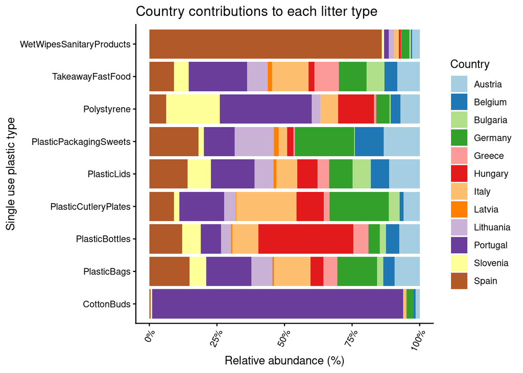

- HeatMaps

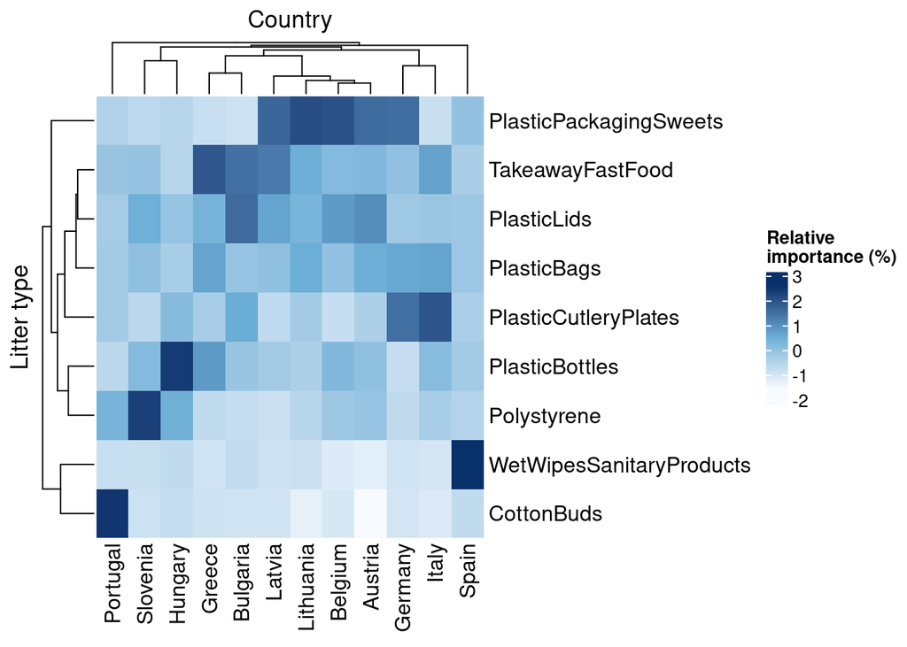

###### SUP Multivariate Perspective

In order to see if there are significant differences across country in the community composition, we will perform a PERMANOVA test:

```
## Permutation test for adonis under reduced model
## Marginal effects of terms
## Permutation: free
## Number of permutations: 999
##
## adonis2(formula = dist_mat_SUP ~ CountryResponsible, data = meta, permutations = 999, by = "margin")
##                     Df SumOfSqs      R2      F Pr(>F)
## CountryResponsible  11   23.006 0.09697 5.2616  0.001 ***
## Residual           539  214.252 0.90303
## Total              550  237.258 1.00000
## ---
## Signif. codes:  0 '***' 0.001 '**' 0.01 '*' 0.05 '.' 0.1 ' ' 1
```

We can look for **heterocedasticity** among countries

```
##
##  Homogeneity of multivariate dispersions
##
## Call: betadisper(d = dist_mat_SUP, group = meta_SUP$CountryResponsible)
##
## No. of Positive Eigenvalues: 9
## No. of Negative Eigenvalues: 0
##
## Average distance to median:
##   austria   belgium  bulgaria   germany    greece   hungary     italy    latvia
##    0.6196    0.6059    0.5416    0.5887    0.4907    0.5711    0.6412    0.5485
## lithuania  portugal  slovenia     spain
##    0.5783    0.6154    0.5959    0.6310
##
## Eigenvalues for PCoA axes:
## (Showing 8 of 9 eigenvalues)
##  PCoA1  PCoA2  PCoA3  PCoA4  PCoA5  PCoA6  PCoA7  PCoA8
## 63.710 39.977 35.962 29.495 22.832 18.822 15.019  9.756
```

```
##
## Permutation test for homogeneity of multivariate dispersions
## Permutation: free
## Number of permutations: 999
##
## Response: Distances
##            Df  Sum Sq  Mean Sq      F N.Perm Pr(>F)
## Groups     11  0.4642 0.042201 1.5106    999  0.144
## Residuals 539 15.0577 0.027936
```

If we need to parametrize this model, we should use a Mixed Multivariate Model (necessary?)

but What are the items that explains these differences?

The answer will be addressed by performing a **Multivariate Random Forest**.

```
##
## Call:
##  randomForest(x = comm_hel_SUP, y = as.factor(meta_SUP$CountryResponsible),      ntree = 500, importance = TRUE)
##                Type of random forest: classification
##                      Number of trees: 500
## No. of variables tried at each split: 3
##
##         OOB estimate of  error rate: 73.68%
## Confusion matrix:
##           austria belgium bulgaria germany greece hungary italy latvia
## austria        15       3        0      14      0       0     5      0
## belgium         3       9        1       5      0       0     4      0
## bulgaria        2       1        5       0      0       0     2      0
## germany        10       3        0      32      0       1     6      0
## greece          2       0        0       0      0       1     7      0
## hungary         2       1        1       0      0       4     5      0
## italy           7       4        0       8      0       2    17      0
## latvia          2       2        0       1      0       0     0      0
## lithuania      12       9        0      20      0       0     4      0
## portugal        9       6        1       6      0       0     4      0
## slovenia        2       1        0       2      1       0     6      0
## spain          11      10        1      15      0       1     9      0
##           lithuania portugal slovenia spain class.error
## austria          21        5        1    10   0.7972973
## belgium          15        2        0    10   0.8163265
## bulgaria          0        0        0     0   0.5000000
## germany          22        4        0     8   0.6279070
## greece            0        0        1     0   1.0000000
## hungary           2        0        0     0   0.7333333
## italy             5        0        1     7   0.6666667
## latvia            4        0        0     1   1.0000000
## lithuania        35        1        1     8   0.6111111
## portugal          6        6        1     6   0.8666667
## slovenia          5        4        1     2   0.9583333
## spain            13        3        2    21   0.7558140
```

Decisions have to be taken carefully since the prediction accuracy is very low (0.26). Furthermore, the estimated error rate (OOB) is high, so conclusion have to be taken with care.

Even though, the more important (differential across countries) litter components are:

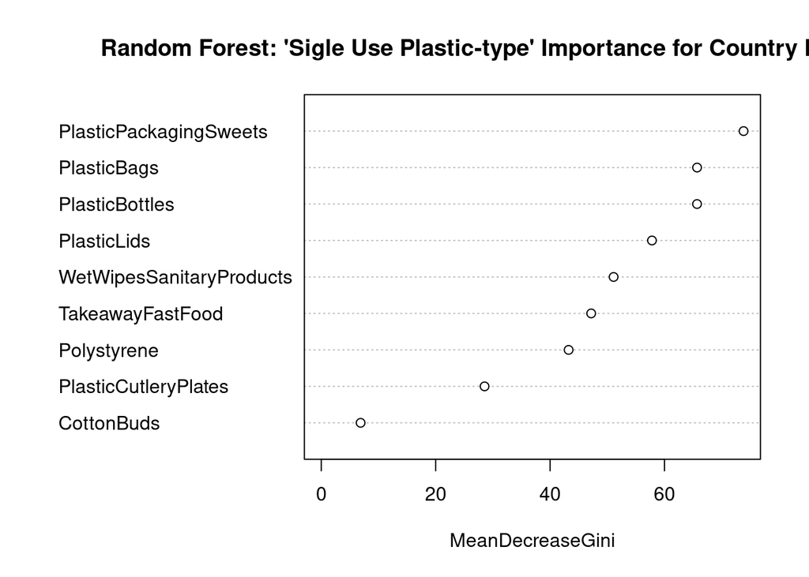

This plot of variable importance importance is telling us:

- A large `MeanDecreaseAccuracy` (**MDA**) means that, when you break the relationship between that predictor and the response, the model’s accuracy suffers a lot → it’s an important predictor for correct country assignments.
- **MDA** is generally the more reliable gauge of predictive importance, since it directly measures impact on OOB‐accuracy.
- A large `MeanDecreaseGini` (**MDG**) means that X frequently appears in high‑up the tree splits and yields big purity gains → it’s structurally important to partitioning the data.
  - **MDG** is faster to compute and tells you which features the trees “prefer” splitting on, but can overweight high–cardinality or continuous variables.

Finally, we will perform a Principal Component Analysis (PCA) to see correlation among litter items and *possible* associations with countries

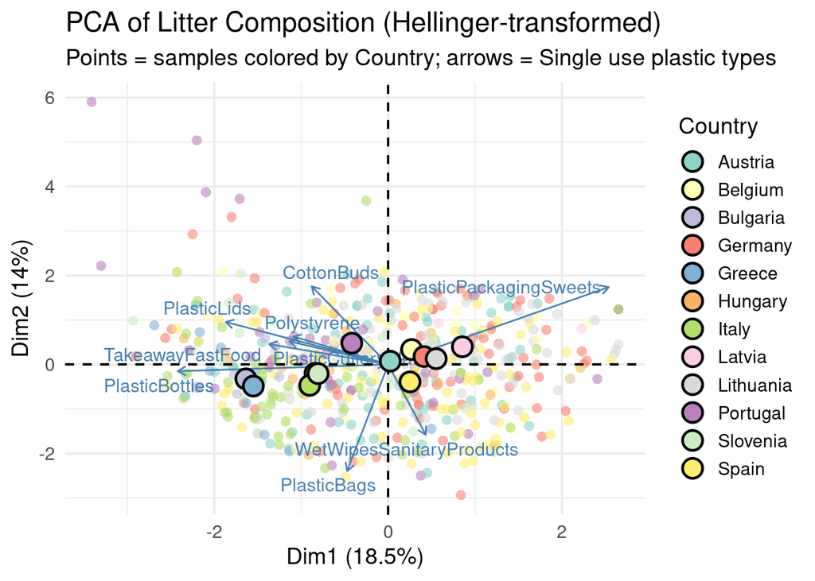

And the most important Items for the two forst principal components are:

- First PC

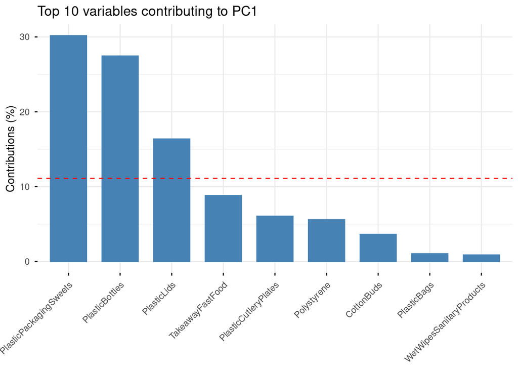

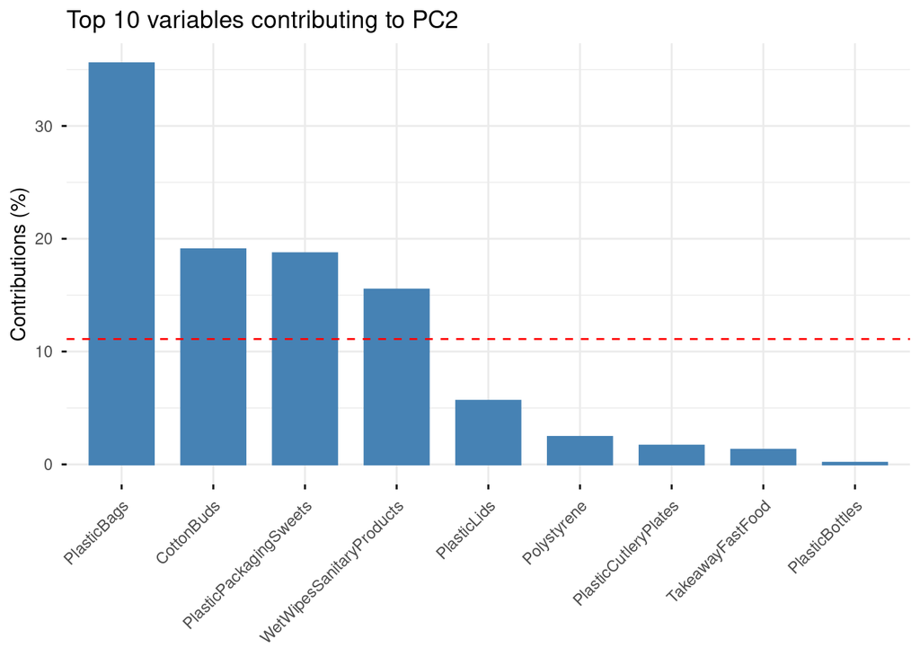

## Floating DATA

### Data loading

| DatasetID | CountryResponsible | SamplingYear | SamplingAttempted | DatasetQualified | SamplingDate | SamplingCoordinatesLatitude | SamplingCoordinatesLongitude | SamplingRiverSystem | FloatingMacro_AttemptedSampling | FloatingMacro_Qualified | FloatingMacro_ObservationTimeInMinutes | FloatingMacro_RiverWidth | FloatingMacro_ObservedWidth | FloatingMacro_AmountOfFloatingMacrolitter |
| --- | --- | --- | --- | --- | --- | --- | --- | --- | --- | --- | --- | --- | --- | --- |
| at_6270 | Austria | 2022 | 1 | 1 | 2022-10-18 | 48.04275 | 14.421917 | danube | 1 | 1 | 29.0 | 28 | 28 | 2 |
| at_6297 | Austria | 2022 | 1 | 1 | 2022-10-22 | 48.26034 | 13.034405 | danube | 1 | 1 | 30.0 | 195 | 6 | 0 |
| at_6349 | Austria | 2022 | 1 | 1 | 2022-10-19 | 48.07639 | 14.457147 | danube | 1 | 1 | 55.0 | 200 | 200 | 0 |
| at_6372 | Austria | 2022 | 1 | 1 | 2022-11-10 | 48.25968 | 13.034020 | danube | 1 | 1 | 60.0 | 11.21 | 11.33 | 1 |
| at_6382 | Austria | 2022 | 1 | 1 | 2022-11-08 | 47.11828 | 13.814191 | danube | 1 | 1 | 60.0 | 27 | 27 | 4 |
| at_6393 | Austria | 2022 | 1 | 1 | 2022-11-09 | 46.58301 | 13.841153 | danube | 1 | 1 | 30.0 | 21 | 7 | 0 |
| at_6414 | Austria | 2022 | 1 | 1 | 2022-11-11 | 48.22545 | 14.316103 | danube | 1 | 1 | 60.0 | 180 | 30 | 0 |
| at_6448 | Austria | 2022 | 1 | 1 | 2022-11-11 | 46.60477 | 14.278000 | danube | 1 | 1 | 30.0 | 9 | 9 | 7 |
| at_6703 | Austria | 2023 | 1 | 1 | 2023-05-10 | 48.38358 | 14.187583 | danube | 1 | 1 | 30.0 | 8 | 8 | 0 |
| at_6718 | Austria | 2023 | 1 | 1 | 2023-05-24 | 48.84332 | 15.500350 | danube | 1 | 1 | 30.0 | 27.7 | 13.85 | 0 |

[output cut: 365 more lines]

#### Sampling Effor for Floating Data

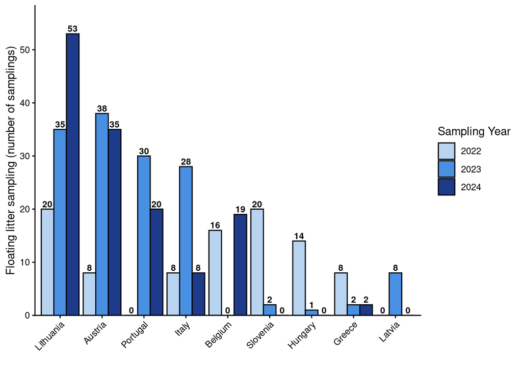

#### Macrolitter Flow calculation

The variable `FlowMacrolitter` is represented as the Number of floating macrolitter $m^{-1}$ $h^{-1}$.

| DatasetID | CountryResponsible | SamplingYear | SamplingAttempted | DatasetQualified | SamplingDate | SamplingCoordinatesLatitude | SamplingCoordinatesLongitude | SamplingRiverSystem | FloatingMacro_AttemptedSampling | FloatingMacro_Qualified | FloatingMacro_ObservationTimeInMinutes | FloatingMacro_RiverWidth | FloatingMacro_ObservedWidth | FloatingMacro_AmountOfFloatingMacrolitter | TimeInHours | RiverWidth | FlowMacrolitter |
| --- | --- | --- | --- | --- | --- | --- | --- | --- | --- | --- | --- | --- | --- | --- | --- | --- | --- |
| at_6270 | Austria | 2022 | 1 | 1 | 2022-10-18 | 48.04275 | 14.421917 | danube | 1 | 1 | 29.0 | 28 | 28 | 2 | 0.4833333 | 62 | 0.066740823 |
| at_6297 | Austria | 2022 | 1 | 1 | 2022-10-22 | 48.26034 | 13.034405 | danube | 1 | 1 | 30.0 | 195 | 6 | 0 | 0.5000000 | 98 | 0.000000000 |
| at_6349 | Austria | 2022 | 1 | 1 | 2022-10-19 | 48.07639 | 14.457147 | danube | 1 | 1 | 55.0 | 200 | 200 | 0 | 0.9166667 | 47 | 0.000000000 |
| at_6372 | Austria | 2022 | 1 | 1 | 2022-11-10 | 48.25968 | 13.034020 | danube | 1 | 1 | 60.0 | 11.21 | 11.33 | 1 | 1.0000000 | 17 | 0.058823529 |
| at_6382 | Austria | 2022 | 1 | 1 | 2022-11-08 | 47.11828 | 13.814191 | danube | 1 | 1 | 60.0 | 27 | 27 | 4 | 1.0000000 | 60 | 0.066666667 |
| at_6393 | Austria | 2022 | 1 | 1 | 2022-11-09 | 46.58301 | 13.841153 | danube | 1 | 1 | 30.0 | 21 | 7 | 0 | 0.5000000 | 103 | 0.000000000 |
| at_6414 | Austria | 2022 | 1 | 1 | 2022-11-11 | 48.22545 | 14.316103 | danube | 1 | 1 | 60.0 | 180 | 30 | 0 | 1.0000000 | 69 | 0.000000000 |
| at_6448 | Austria | 2022 | 1 | 1 | 2022-11-11 | 46.60477 | 14.278000 | danube | 1 | 1 | 30.0 | 9 | 9 | 7 | 0.5000000 | 119 | 0.117647059 |
| at_6703 | Austria | 2023 | 1 | 1 | 2023-05-10 | 48.38358 | 14.187583 | danube | 1 | 1 | 30.0 | 8 | 8 | 0 | 0.5000000 | 110 | 0.000000000 |
| at_6718 | Austria | 2023 | 1 | 1 | 2023-05-24 | 48.84332 | 15.500350 | danube | 1 | 1 | 30.0 | 27.7 | 13.85 | 0 | 0.5000000 | 25 | 0.000000000 |

[output cut: 365 more lines]

#### Macrolitter Flow Visualization

##### Differences across countries

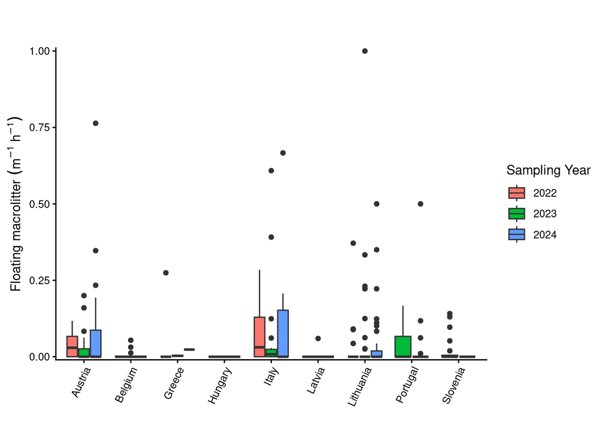

- **Statistical test**
  - Generalize linear mixed model (Tweedie)

  Family error distribution was selected due to the data restriction (only positive values with high numbers of zeroes)

```
##  Family: tweedie  ( log )
## Formula:          FlowMacrolitter ~ CountryResponsible
## Data: FlowData
##
##       AIC       BIC    logLik -2*log(L)  df.resid
##     290.0     331.8    -134.0     268.0       320
##
##
## Dispersion parameter for tweedie family (): 2.16
##
## Conditional model:
##                               Estimate Std. Error z value Pr(>|z|)
## (Intercept)                    -3.0551     0.3049 -10.018  < 2e-16 ***
## CountryResponsibleBelgium      -2.1601     1.0099  -2.139   0.0324 *
## CountryResponsibleGreece        2.4984     0.5812   4.299 1.72e-05 ***
## CountryResponsibleHungary     -49.0697 22469.0664  -0.002   0.9983
## CountryResponsibleItaly         0.6001     0.5143   1.167   0.2433
## CountryResponsibleLatvia        1.5887     0.8014   1.982   0.0474 *
## CountryResponsibleLithuania     0.0708     0.3976   0.178   0.8587
## CountryResponsiblePortugal      1.0816     0.4367   2.477   0.0132 *
## CountryResponsibleSlovenia     -0.8575     0.7405  -1.158   0.2469
## ---
## Signif. codes:  0 '***' 0.001 '**' 0.01 '*' 0.05 '.' 0.1 ' ' 1
```

|  | Df | AIC | BIC | logLik | deviance | Chisq | Chi Df | Pr(>Chisq) |
| --- | --- | --- | --- | --- | --- | --- | --- | --- |
| mod_null | 3 | 318.2739 | 329.6803 | -156.1370 | 312.2739 | NA | NA | NA |
| mod_full | 11 | 290.0082 | 331.8315 | -134.0041 | 268.0082 | 44.26567 | 8 | 5.068326e-07 |

- Posthoc with multple comparisons

|  | contrast | ratio | SE | df | null | z.ratio | p.value |
| --- | --- | --- | --- | --- | --- | --- | --- |
| 1 | Austria / Belgium | 8.671752e+00 | 8.757255e+00 | Inf | 1 | 2.138980600 | 0.4464309150 |
| 2 | Austria / Greece | 8.221540e-02 | 4.778022e-02 | Inf | 1 | -4.299017260 | 0.0005807215 |
| 3 | Austria / Hungary | 2.045041e+21 | 4.595016e+25 | Inf | 1 | 0.002183878 | 1.0000000000 |
| 4 | Austria / Italy | 5.487760e-01 | 2.822611e-01 | Inf | 1 | -1.166654849 | 0.9633969547 |
| 5 | Austria / Latvia | 2.041962e-01 | 1.636342e-01 | Inf | 1 | -1.982478005 | 0.5556861400 |
| 6 | Austria / Lithuania | 9.316487e-01 | 3.704281e-01 | Inf | 1 | -0.178064822 | 0.9999999697 |
| 7 | Austria / Portugal | 3.390504e-01 | 1.480505e-01 | Inf | 1 | -2.476986158 | 0.2431155310 |
| 8 | Austria / Slovenia | 2.357258e+00 | 1.745566e+00 | Inf | 1 | 1.157989249 | 0.9649953461 |
| 9 | Belgium / Greece | 9.480830e-03 | 1.026196e-02 | Inf | 1 | -4.303883306 | 0.0005683707 |
| 10 | Belgium / Hungary | 2.358279e+20 | 5.298832e+24 | Inf | 1 | 0.002087743 | 1.0000000000 |

[output cut: 26 more lines]